# Summary statistics and visualisations

Bernard Silenou and Henrik Schanze

2023-12-11

# Data Visualization

- After importing and cleaning your data, the next aim before modelling is to understand your data.
- Essential tools to attain this aim are *summary statistics* and *plots*.

## Goals

- Be able to calculate a range of summary statistics on numeric data
- Be able to draw plots and export out of R

# Summary statistics

Summary statistics are used to summarize data by precise numeric values to develop an understanding of the data and communicate its key information as simply as possible. The basic measurements often used for this are

To demonstrate these and other things we will use the `obama_vs_mccain` data set, that is part of the `learningr` and contains the fractions of people voting for Obama and McCain in the 2008 US presidential elections. We want to get an idea of the votes for Obama.

```r
load(file ="data/obama_vs_mccain.rda")
votesObama = obama_vs_mccain$Obama
```

### Measure of location:

As a first measurement we calculate the arithmetic mean, which is the sum of all data points divided by the number of data points, of the votes by `mean()`.

```r
mean(votesObama)
```

```
## [1] 51.28941
```

```r
median(votesObama)
```

```
## [1] 51.38
```

### Measure of range:

To get the smallest fraction of votes for Obama we could use `min()`.

```r
min(votesObama)
```

```
## [1] 32.54
```

Similar to that we can get the highest amount of votes by `max()`.

```r
max(votesObama)
```

```
## [1] 92.46
```

To get the data points that separates the set in different sections, e.g. the first quartile being located above $25\%$ and below $75\%$ of the other data points, we can use `quantile()` and use its second argument to determine the fraction of data points below the value.

```r
quantile(votesObama, 0.25)
```

```
##    25%
## 42.755
```

```r
quantile(votesObama)
```

```
##     0%    25%    50%    75%   100%
## 32.540 42.755 51.380 57.335 92.460
```

**Quick exercise**: Express `min()`, `max()` and `median()` via `quantile()`.

```r
min(votesObama)
```

```
## [1] 32.54
```

```r
quantile(votesObama, )
```

```
##     0%    25%    50%    75%   100%
## 32.540 42.755 51.380 57.335 92.460
```

```r
max(votesObama)
```

```
## [1] 92.46
```

```r
quantile(votesObama, )
```

```
##     0%    25%    50%    75%   100%
## 32.540 42.755 51.380 57.335 92.460
```

```r
median(votesObama)
```

```
## [1] 51.38
```

```r
quantile(votesObama, )
```

```
##     0%    25%    50%    75%   100%
## 32.540 42.755 51.380 57.335 92.460
```

### Measure of variation:

To get the range of our data, which is simply the smallest and largest values of the data, we can use `range()`.

```r
range(votesObama)
```

```
## [1] 32.54 92.46
```

For the standard deviation of your data, i.e. the average distance of data points to its mean, we can use `sd()`.

`sd(x)`: standard deviation, square sd to get variance or use `var(x)`

```r
sd(votesObama)
```

```
## [1] 11.0938
```

Sometimes the variance, determined by `var()` is used instead of the standard variation, which is just the square root of the variance.

```r
var(votesObama)
```

```
## [1] 123.0723
```

```r
sd(votesObama)**2
```

```
## [1] 123.0723
```

The interquartile range is the distance between the $25\%$ and $75\%$ percentile, and incorporates $50\%$ of the data including the median. The calculated by one command, we can use `IQR()`.

```r
IQR(votesObama)
```

```
## [1] 14.58
```

### Measure of position or count:

Sometimes we are interested in the data at certain positions. To access the first value in the data we could use `[1]` following the data set.

```r
votesObama[1]
```

```
## [1] 38.74
```

Since `length()` gives us the length of the data vector, we can use it to access the last element.

```r
votesObama[length(votesObama)]
```

```
## [1] 32.54
```

**Quick exercise**: what is the last last but one element in `votesObama`?

### Other summary statistics functions:

To get an statistical overview over the data, we can use `summary()`.

```r
summary(votesObama)
```

```
##    Min. 1st Qu.  Median    Mean 3rd Qu.    Max.
##   32.54   42.76   51.38   51.29   57.34   92.46
```

```r
summary(obama_vs_mccain)
```

```
##         State        Region       Obama           McCain         Turnout
##  Alabama   : 1   IV     : 8   Min.   :32.54   Min.   : 6.53   Min.   :50.80
##  Alaska    : 1   I      : 6   1st Qu.:42.76   1st Qu.:40.39   1st Qu.:61.05
##  Arizona   : 1   III    : 6   Median :51.38   Median :46.80   Median :64.90
##  Arkansas  : 1   V      : 6   Mean   :51.29   Mean   :47.00   Mean   :64.09
##  California: 1   VIII   : 6   3rd Qu.:57.34   3rd Qu.:55.88   3rd Qu.:67.95
##  Colorado  : 1   VI     : 5   Max.   :92.46   Max.   :65.65   Max.   :78.00
##  (Other)   :45   (Other):14                                   NA's   :4
##   Unemployment      Income        Population          Catholic
##  Min.   :3.40   Min.   :19534   Min.   :  563626   Min.   : 6.00
##  1st Qu.:5.05   1st Qu.:23501   1st Qu.: 1702662   1st Qu.:12.00
##  Median :5.90   Median :25203   Median : 4350606   Median :21.00
##  Mean   :6.01   Mean   :26580   Mean   : 6074128   Mean   :21.67
##  3rd Qu.:7.25   3rd Qu.:28978   3rd Qu.: 6656506   3rd Qu.:29.00
##  Max.   :9.40   Max.   :40846   Max.   :37341989   Max.   :46.00
##                                                    NA's   :2
##    Protestant        Other       Non.religious       Black          Latino
##  Min.   :26.00   Min.   :0.000   Min.   : 5.00   Min.   : 0.4   Min.   : 1.20
##  1st Qu.:46.00   1st Qu.:2.000   1st Qu.:12.00   1st Qu.: 3.1   1st Qu.: 4.30
##  Median :54.00   Median :3.000   Median :15.00   Median : 7.4   Median : 8.20
##  Mean   :53.84   Mean   :3.286   Mean   :16.04   Mean   :11.1   Mean   :10.32
##  3rd Qu.:62.00   3rd Qu.:4.000   3rd Qu.:19.00   3rd Qu.:15.2   3rd Qu.:12.05
##  Max.   :80.00   Max.   :8.000   Max.   :34.00   Max.   :50.7   Max.   :46.30
##  NA's   :2       NA's   :2       NA's   :2
##   Urbanization
##  Min.   :   1.2
##  1st Qu.:  45.8
##  Median : 101.2
##  Mean   : 385.6
##  3rd Qu.: 221.4
##  Max.   :9856.5
##
```

An alternative to `length()`, that is also useful, when operating with data frames is `dim()`.

```r
length(votesObama)
```

```
## [1] 51
```

```r
dim(obama_vs_mccain)
```

```
## [1] 51 15
```

```r
dim(obama_vs_mccain)[1] # the same as nrow(obama_vs_mccain)
```

```
## [1] 51
```

```r
dim(obama_vs_mccain)[2] # the same as ncol(obama_vs_mccain)
```

```
## [1] 15
```

If we have categorical data and want an overview about the distribution among the categories we can use `table()`. For example we could examine the amount of missing data by using `table()` after applying `is.na()`.

```r
table(is.na(votesObama))
```

```
##
## FALSE
##    51
```

```r
table(is.na(votesObama), useNA = "always")
```

```
##
## FALSE  <NA>
##    51     0
```

Get get a list of all answers given we could call `unique()` on the data set. The length of its return also tells us how many different answers there are.

```r
unique(obama_vs_mccain$Region)
```

```
##  [1] IV   X    IX   VI   VIII I    III  V    VII  II
## Levels: I II III IV IX V VI VII VIII X
```

```r
length(unique(obama_vs_mccain$Region))
```

```
## [1] 10
```

To calculate the correlation coefficient (pearson by default) of two numeric vectors, we can use `cor()`, to get a hint if there might be a link between both variables.

```r
cor(obama_vs_mccain$Obama, obama_vs_mccain$McCain)
```

```
## [1] -0.9981189
```

Same wise we could calculate the covariance (also pearson by default) by `cov()`.

```r
with(obama_vs_mccain, cov(Obama, McCain)) # the same as cov(obama_vs_mccain$Obama, obama_vs_mccain$McCain)
```

```
## [1] -121.6998
```

# Visualizations

## Systems of plots

R has three systems of graphics: *base*, *grid*, and *lattice*.

**Base graphics** is easy to get started with but hard to extend to new graph types. It will be used for a greater part of this section.

**Grid graphics** provides greater flexibility but require writing much lines of code. Example is package ggplot2–most modern and widely used.

**Lattice graphics** is built on top of the grid system, providing high-level functions for all the common plot types. Plot output can be saved as objects, edited and later plotted.

The three systems are, sadly, mostly incompatible, thus recommended to choose one system for a project. ggplot2 is a good choice.

## Heat maps

When we want to visualize the connection of two categorical variables our set of tools is quite limited. As an example we have a look at the data set `mtcars` incorporating data about 32 cars. We want to visualize the (possible) link between the number of cylinders `cyl` and number of (forward) gears `gear`.

Since this data set is part of base **R**, we can use the R help to get a better understanding what the columns mean.

```r
?mtcars
```

One of the most simple solutions is to use a cross table. To create one, we can use `table()` and hand over the column names we are interested in (you can hand in more than two, but the cases that this is useful are quite limited). We could also hand over names for the row and column names via `dnn`.

```r
table(mtcars$cyl, mtcars$gear, dnn = list("cylinder","gears"))
```

```
##         gears
## cylinder  3  4  5
##        4  1  8  2
##        6  2  4  1
##        8 12  0  2
```

Depending on the number of categories and magnitude of numbers, spotting an underlying correlation might be quite hard. A way to spot connections faster is to color-code the cells of the cross table The resulting graphic is called a heat map.

### Using base R

To transform a cross table into heat map we can give the cross table to `heatmap()`.

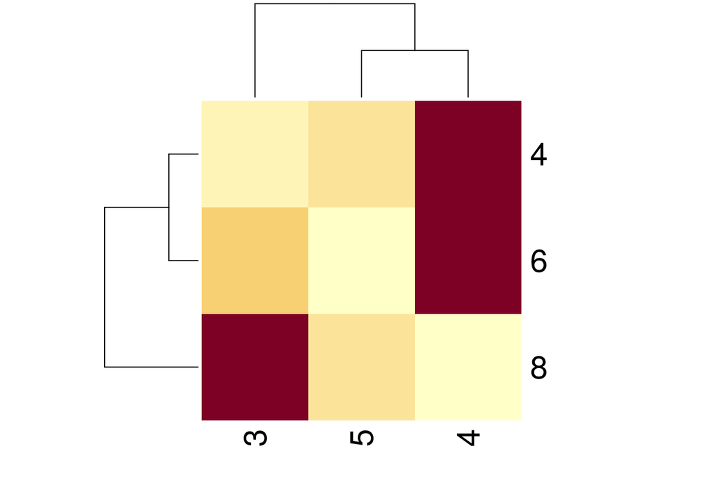

```r
heatmap(table(mtcars$cyl, mtcars$gear))
```

Without any further arguments `heatmap()` also creates a dendrogram and reorders the categories according to its clustering. To deactivate that we have to set the arguments `Rowv` and `Colv` to `NA` and by setting `revC=TRUE` we get the same cell order than in the cross table.

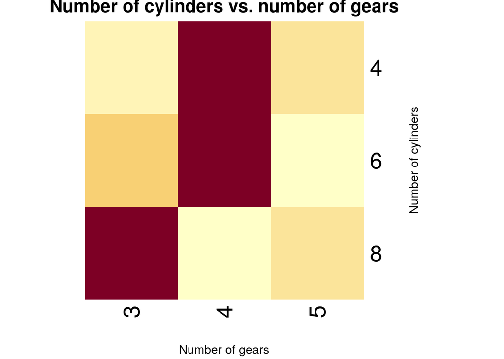

```r
heatmap(table(mtcars$cyl, mtcars$gear), Rowv = NA, Colv = NA, revC = TRUE,
        main = "Number of cylinders vs. number of gears",
        xlab = "Number of gears",
        ylab = "Number of cylinders")
```

From time to time it is reasonable to scale the color-coding according to all values, column wise or row wise (the default). We could set this by the argument `scale`.

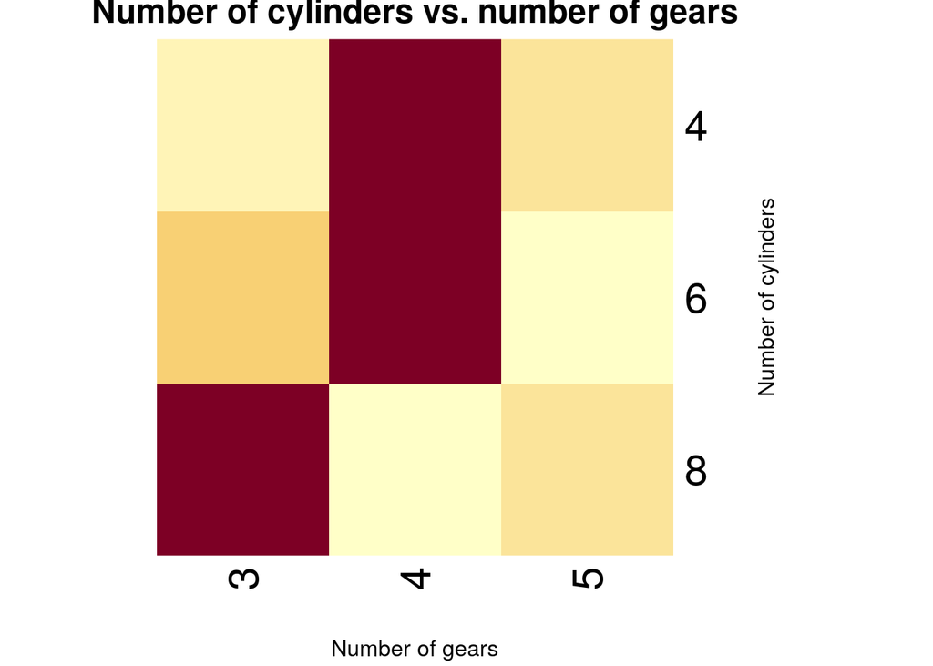

```r
heatmap(table(mtcars$cyl, mtcars$gear), Rowv = NA, Colv = NA, revC = TRUE,
        scale = "row",
        main = "Number of cylinders vs. number of gears",
        xlab = "Number of gears",
        ylab = "Number of cylinders")
```

### Using ggplot2 package

First of all we have to load the `ggplot2` package. If `ggplot2` is not installed, please use `install.packages("ggplot2")` to do so.

```r
library(ggplot2)
```

Creating a heat map with `ggplot2` requires a little bit extra work, but it enables us to adjust the graphic in more detail. We also start with the initial cross table, but turn it into a data frame

```r
df_cars <- data.frame(table(mtcars$cyl, mtcars$gear, dnn = list("cylinder","gears")))

df_cars
```

```
##   cylinder gears Freq
## 1        4     3    1
## 2        6     3    2
## 3        8     3   12
## 4        4     4    8
## 5        6     4    4
## 6        8     4    0
## 7        4     5    2
## 8        6     5    1
## 9        8     5    2
```

Now we can hand over that data frame to `ggplot()` and specify in `aes()` which variable (from the data frame) should be on the `x` axis, on the `y` axis and which numbers should the cells be filled with (`fill`). Finally we can add title and labels as before.

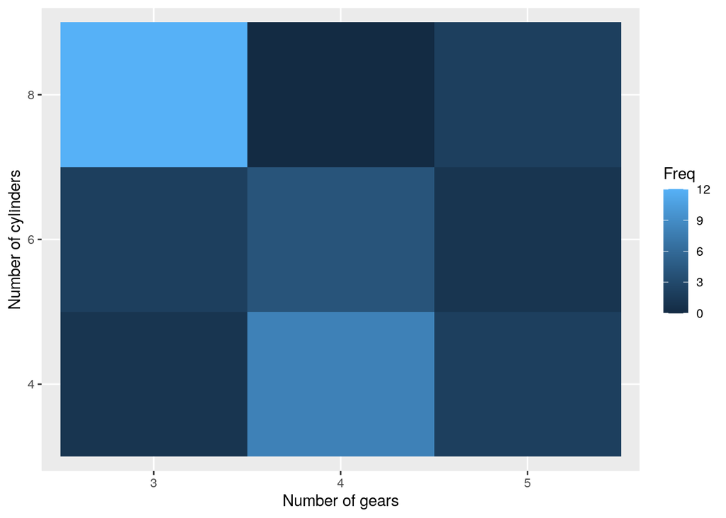

```r
ggplot(df_cars, aes(x = gears, y = cylinder, fill = Freq)) +
  geom_tile() +
  labs(main = "Number of cylinders vs. number of gears",
       x = "Number of gears",
       y = "Number of cylinders")
```

Adjusting the scaling of this heat map is also a little bit more complex than before, since we have to apply `scale()` to the initial table. The argument `center` determines the new central value and the argument `scale` determines the way we scale the values. `scale = FALSE` does no scaling, `scale = TRUE` gives row scaled values and `scale = c(15,12,5)` results (in this case) in a column scaling.

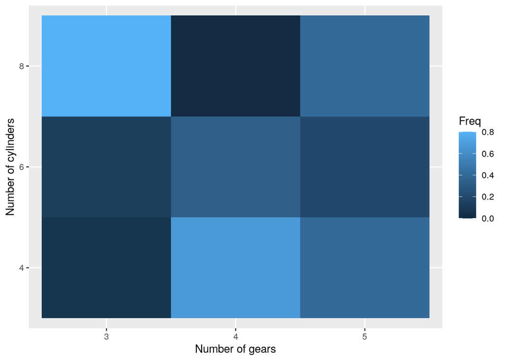

```r
df_cars_scaled <- data.frame(scale(
  table(mtcars$cyl, mtcars$gear, dnn = list("cylinder","gears")),
  center = FALSE, scale = c(15,12,5)))

ggplot(df_cars_scaled, aes(x = gears, y = cylinder, fill = Freq)) +
  geom_tile() +
  labs(main = "Number of cylinders vs. number of gears",
       x = "Number of gears",
       y = "Number of cylinders")
```

## Bar chart

A bar chart displays the amount of of a discrete categorical data via the height or length of a bar. Using a bar chart is therefore a visual alternative for using a table.

As an example we will again use the data set `mtcars` which includes information about 32 different cars, e.g. the number of cylinders `cyl`.

```r
mtcars
```

```
##                      mpg cyl  disp  hp drat    wt  qsec vs am gear carb
## Mazda RX4           21.0   6 160.0 110 3.90 2.620 16.46  0  1    4    4
## Mazda RX4 Wag       21.0   6 160.0 110 3.90 2.875 17.02  0  1    4    4
## Datsun 710          22.8   4 108.0  93 3.85 2.320 18.61  1  1    4    1
## Hornet 4 Drive      21.4   6 258.0 110 3.08 3.215 19.44  1  0    3    1
## Hornet Sportabout   18.7   8 360.0 175 3.15 3.440 17.02  0  0    3    2
## Valiant             18.1   6 225.0 105 2.76 3.460 20.22  1  0    3    1
## Duster 360          14.3   8 360.0 245 3.21 3.570 15.84  0  0    3    4
## Merc 240D           24.4   4 146.7  62 3.69 3.190 20.00  1  0    4    2
## Merc 230            22.8   4 140.8  95 3.92 3.150 22.90  1  0    4    2
## Merc 280            19.2   6 167.6 123 3.92 3.440 18.30  1  0    4    4
## Merc 280C           17.8   6 167.6 123 3.92 3.440 18.90  1  0    4    4
## Merc 450SE          16.4   8 275.8 180 3.07 4.070 17.40  0  0    3    3
## Merc 450SL          17.3   8 275.8 180 3.07 3.730 17.60  0  0    3    3
## Merc 450SLC         15.2   8 275.8 180 3.07 3.780 18.00  0  0    3    3
## Cadillac Fleetwood  10.4   8 472.0 205 2.93 5.250 17.98  0  0    3    4
## Lincoln Continental 10.4   8 460.0 215 3.00 5.424 17.82  0  0    3    4
## Chrysler Imperial   14.7   8 440.0 230 3.23 5.345 17.42  0  0    3    4
## Fiat 128            32.4   4  78.7  66 4.08 2.200 19.47  1  1    4    1
## Honda Civic         30.4   4  75.7  52 4.93 1.615 18.52  1  1    4    2
## Toyota Corolla      33.9   4  71.1  65 4.22 1.835 19.90  1  1    4    1
## Toyota Corona       21.5   4 120.1  97 3.70 2.465 20.01  1  0    3    1
## Dodge Challenger    15.5   8 318.0 150 2.76 3.520 16.87  0  0    3    2
## AMC Javelin         15.2   8 304.0 150 3.15 3.435 17.30  0  0    3    2
## Camaro Z28          13.3   8 350.0 245 3.73 3.840 15.41  0  0    3    4
## Pontiac Firebird    19.2   8 400.0 175 3.08 3.845 17.05  0  0    3    2
## Fiat X1-9           27.3   4  79.0  66 4.08 1.935 18.90  1  1    4    1
## Porsche 914-2       26.0   4 120.3  91 4.43 2.140 16.70  0  1    5    2
## Lotus Europa        30.4   4  95.1 113 3.77 1.513 16.90  1  1    5    2
## Ford Pantera L      15.8   8 351.0 264 4.22 3.170 14.50  0  1    5    4
## Ferrari Dino        19.7   6 145.0 175 3.62 2.770 15.50  0  1    5    6
## Maserati Bora       15.0   8 301.0 335 3.54 3.570 14.60  0  1    5    8
## Volvo 142E          21.4   4 121.0 109 4.11 2.780 18.60  1  1    4    2
```

```r
table(mtcars$cyl, dnn = list("cylinders"))
```

```
## cylinders
##  4  6  8
## 11  7 14
```

### Using base R

As we can see the data set `mtcars` lists different cars in their rows including information about the number of cylinders `cyl`. To create a bar chart depicting the number of cars with a certain amount of cylinders, we can not use this raw data, since this information is not directly part of the data set.

To create such a bar chart we first have to extract the required information out of the data set. Luckily `table()` does exactly what we want. If we use it and turn the result via `data.frame()` into a data frame (so we have access to the row listing the counts), we can use `barplot()` to create the respective bar chart.

```r
cyl_table <- data.frame(table(mtcars$cyl, dnn = list("cylinders")))
cyl_table
```

```
##   cylinders Freq
## 1         4   11
## 2         6    7
## 3         8   14
```

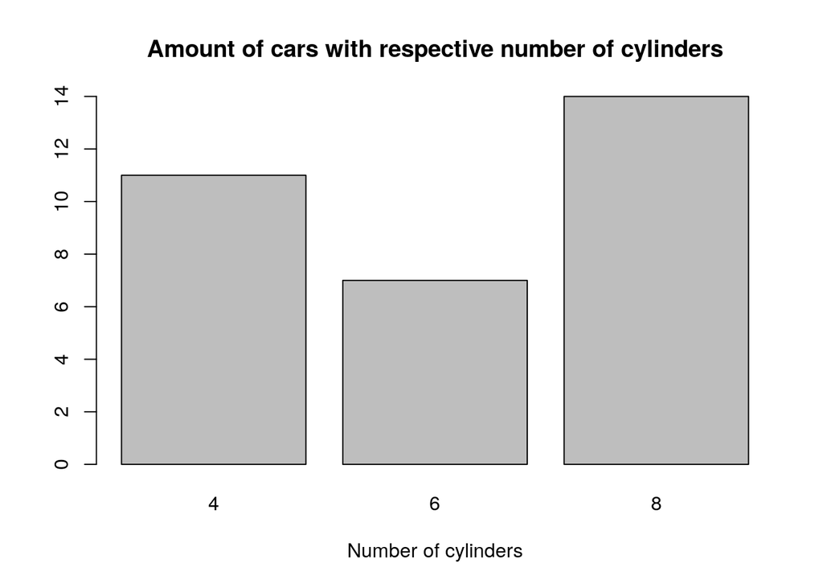

```r
barplot(height = cyl_table$Freq, names = cyl_table$cylinders,
        main = "Amount of cars with respective number of cylinders",
        xlab = "Number of cylinders")
```

### Using ggplot2 package

If not already done, please load the `ggplot2` package.

```r
library(ggplot2)
```

Using `ggplot2` has the advantage that we can feed our data directly to the ‘plotting’-function without count the values of which amount we are interested in ‘manually’. We can give our data set to `ggplot()`, and specify in `aes()` that we are interested to plot `cyl` a long the x-axis, by setting `x = cyl`. Since the numbers in `cyl` represent categories and not (directly) numbers, we have to use `as.factor()` on the variable `cyl`. After this initial step, we could create the bar chart with adding `geom_bar()`, where we can specify details about the bar chart, and `labs()` to set all kinds of labels for our graphic.

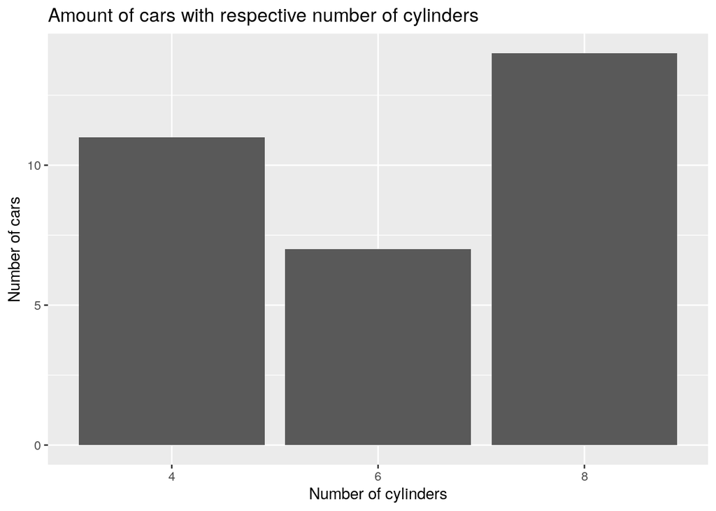

```r
ggplot(mtcars, aes(x = as.factor(cyl))) +
  geom_bar() +
  labs(title = "Amount of cars with respective number of cylinders",
       x = "Number of cylinders",
       y = "Number of cars")
```

## Histogram

Histograms are a very basic way to display an approximation of the distribution of a given variable. In this example we want visualize the data in `airquality` that includes measurements in New York from May to September 1973.

First we have a short look into the data.

```r
head(airquality)
```

```
##   Ozone Solar.R Wind Temp Month Day
## 1    41     190  7.4   67     5   1
## 2    36     118  8.0   72     5   2
## 3    12     149 12.6   74     5   3
## 4    18     313 11.5   62     5   4
## 5    NA      NA 14.3   56     5   5
## 6    28      NA 14.9   66     5   6
```

In the following we want to visualize the distributions of wind speed (measured in miles per hour). To get a first impression of the range of that variable we use `summary()`.

```r
summary(airquality$Wind)
```

```
##    Min. 1st Qu.  Median    Mean 3rd Qu.    Max.
##   1.700   7.400   9.700   9.958  11.500  20.700
```

### Using base R

We want to use histograms to get a visual impression of the recorded wind speeds. A histogram uses bins to collect ranges of data and depicts the number of data points in each bin by its height. In base **R** we can easily create such a plot by using `hist()`. Without additional arguments **R** will distribute the ‘bins’ on its own, but we can also manually adjust the number or width of the used ‘bins’ by the argument `breaks`.

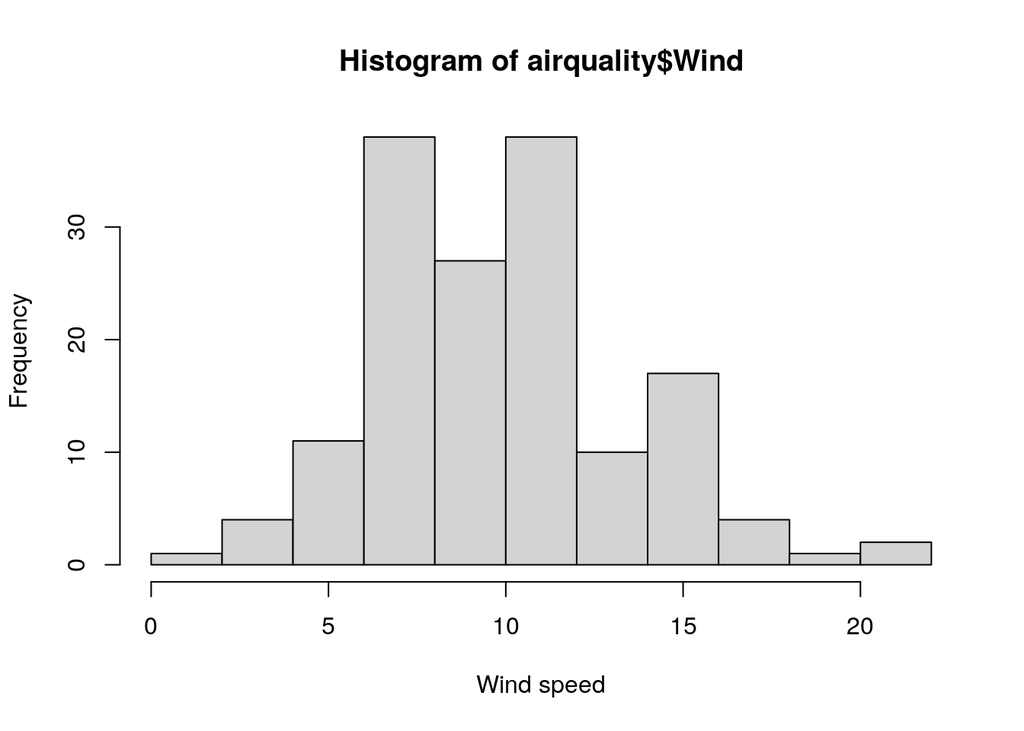

```r
hist(airquality$Wind,
     xlab = "Wind speed")
```

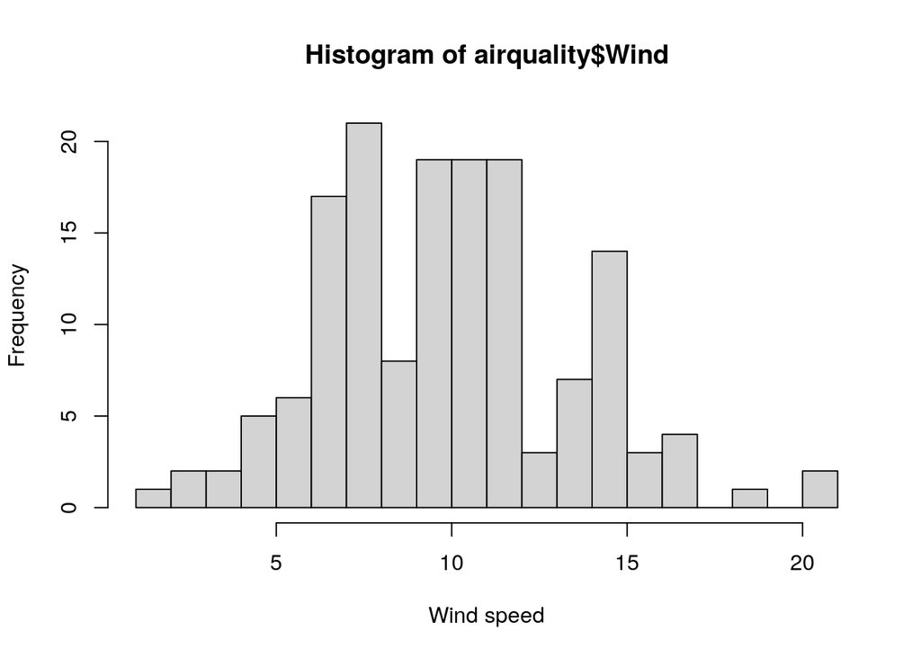

```r
hist(airquality$Wind, breaks = 25,#c(0,seq(5,15,2), 21),
     xlab = "Wind speed")
```

Since it would be interesting to compare the distribution of wind speeds for different months, we want to directly compare two histograms with each other.

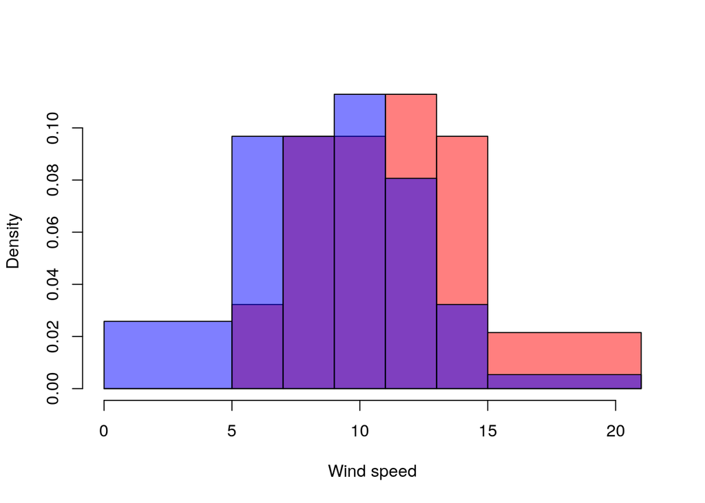

```r
hist(airquality[airquality$Month == 5,]$Wind,
     breaks = c(0,seq(5,15,2), 21), col = rgb(1,0,0,0.5),
     xlab = "Wind speed", main = "")

hist(airquality[airquality$Month == 8,]$Wind,
     breaks = c(0,seq(5,15,2), 21), col = rgb(0,0,1,0.5),
     add = TRUE)
```

### Using ggplot2 package

We want to show the way histograms could be created with `ggplot2`. In case you have not loaded `ggplot2` please execute the following line.

```r
library(ggplot2)
```

We first have to tell `ggplot2` what data we are using by `ggplot()` and specifying that we want to display `Wind` on the x-axis. Afterwards we can create the histogram with `geom_histogram()`. As before not giving any information about the wanted bins leads to `ggplot` deciding how to distribute the bins according to the data. We can either choose the number of bins by `bins`, the width of the bins by `binwidth` or specify where to separate between bins with `breaks`. Each of these arguments overwrites the use of the former.

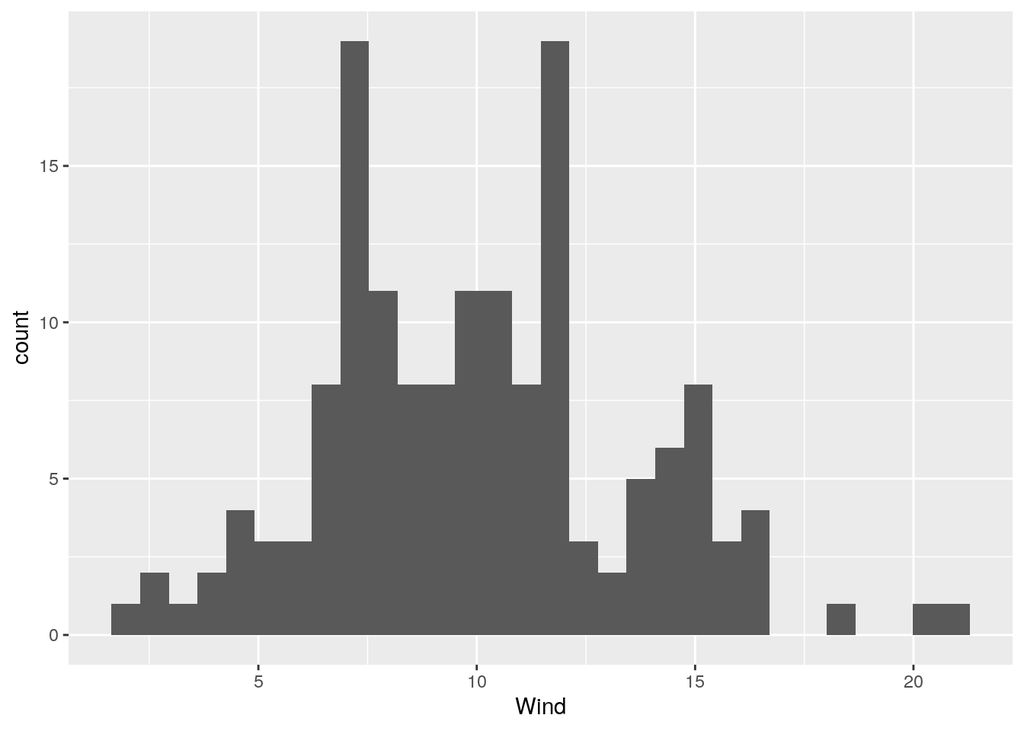

```r
ggplot(airquality, aes(x = Wind)) +
  geom_histogram()
```

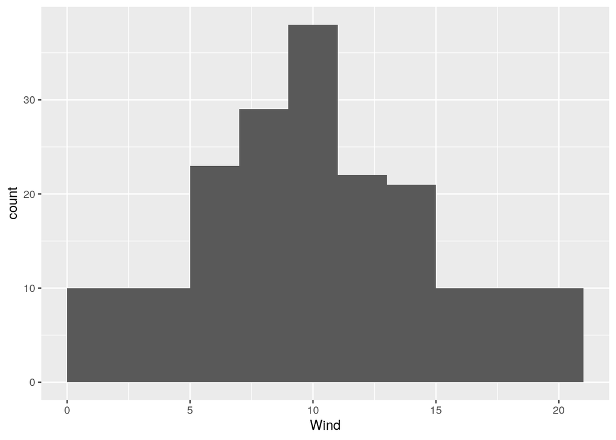

```r
ggplot(airquality, aes(x = Wind)) +
  geom_histogram(breaks = c(0,seq(5,15,2), 21))
```

We can also use `ggplot2` compare two (or more) histograms with each other. In contrast to base R we do this in one single command using `Month` as a factor (notice that we have selected the data for only two different months in the first argument).

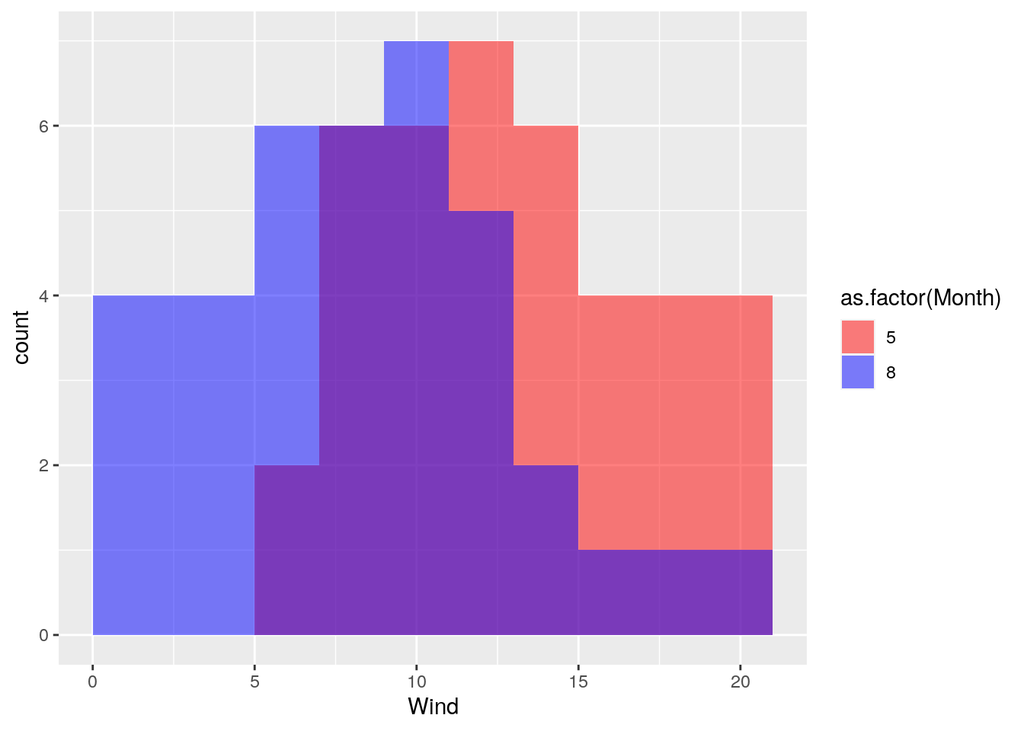

```r
ggplot(airquality[airquality$Month %in% c(5,8),],
       aes(x = Wind, fill = as.factor(Month))) +
  geom_histogram(position="identity", alpha=0.5, breaks=c(0,seq(5,15,2), 21)) +
  scale_fill_manual(values = c(rgb(1,0,0,0.5), rgb(0,0,1,0.5)))
```

## Box plot

A box plot is a visualization of the distribution of numerical data. Will we use the data set `mtcars` which incorporates fuel consumption and ten aspects design and performance for 32 different cars. First we have a short look into our data.

```r
head(mtcars)
```

```
##                    mpg cyl disp  hp drat    wt  qsec vs am gear carb
## Mazda RX4         21.0   6  160 110 3.90 2.620 16.46  0  1    4    4
## Mazda RX4 Wag     21.0   6  160 110 3.90 2.875 17.02  0  1    4    4
## Datsun 710        22.8   4  108  93 3.85 2.320 18.61  1  1    4    1
## Hornet 4 Drive    21.4   6  258 110 3.08 3.215 19.44  1  0    3    1
## Hornet Sportabout 18.7   8  360 175 3.15 3.440 17.02  0  0    3    2
## Valiant           18.1   6  225 105 2.76 3.460 20.22  1  0    3    1
```

As we have seen before we can use `summary()` to get a (numerical) overview about the distribution of the fuel consumption `mpg` (miles per gallon).

```r
summary(mtcars$mpg)
```

```
##    Min. 1st Qu.  Median    Mean 3rd Qu.    Max.
##   10.40   15.43   19.20   20.09   22.80   33.90
```

That may answer some of our question regarding the over all fuel consumption of the cars in the data set, but it es not very easy to gasp and gets very overwhelming if we want to compare different distributions of fuel consumption (e.g. distinguished by number of cylinders).

### Using base R

Using a box plot for visualizing puts all the above information in one graphic.

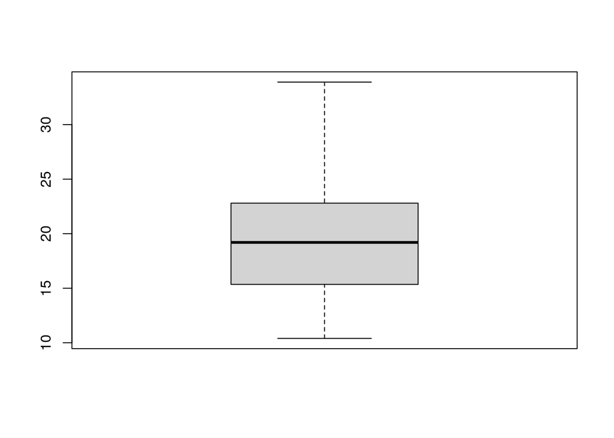

```r
boxplot(mtcars$mpg)
```

Since the single plot includes all the information from before it needs some knowledge to be understood completely.

- The Median is marked by the thick black line inside the grey box.
- The 1st and 3rd quartile are the lower and upper end of the grey box, therefore $50\%$ of the values, including the median, are located inside the grey box.
- The two antennas/whiskers give the range including (roughly) $95\%$ of the data points.
- Values outside this range are sometimes depicted as singular data points.

We can also use box plots to quickly compare the distribution of the fuel consumption for different number of cylinders `cyl` or number of gears `gear`.

To do that we have to give `boxplot` a so called formula describing the relation we are interested in. A formula connects the (numeric) variable we are interested in (e.g. `mgp`) via `~` with the grouping variables, such as `cyl` or `gear`, usually as factors.

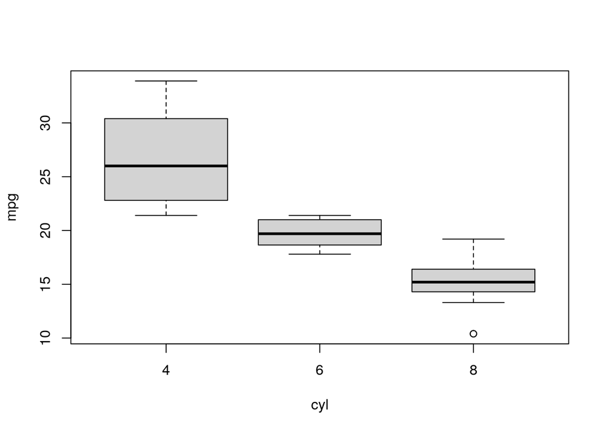

```r
boxplot(mpg ~ cyl, data = mtcars)
```

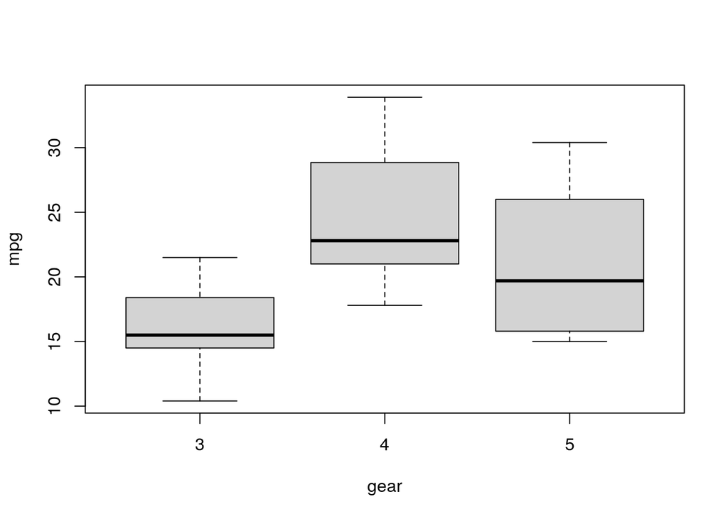

```r
boxplot(mpg ~ gear, data = mtcars)
```

As before with other plots we have some basic options to manipulate the appearance of the plots, e.g. add labels.

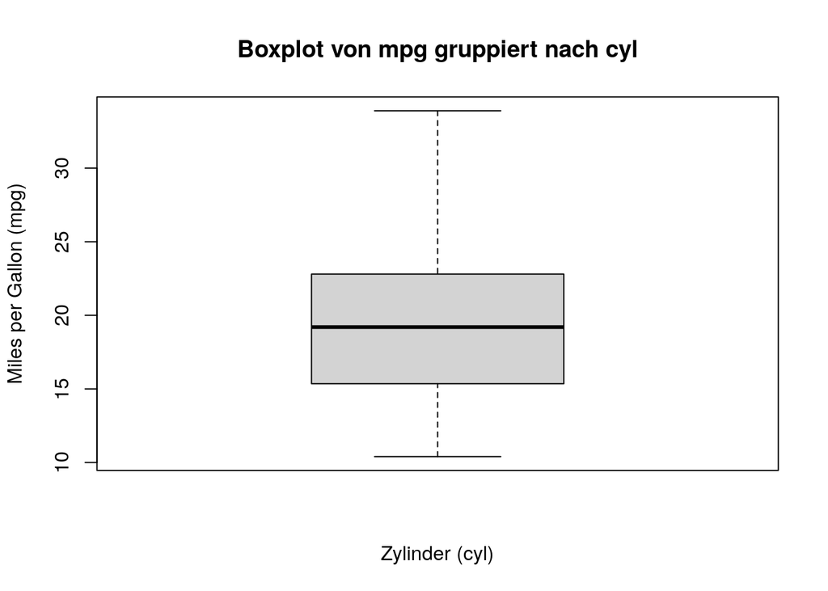

```r
boxplot(mtcars$mpg,
        main="Boxplot von mpg gruppiert nach cyl",
        xlab="Zylinder (cyl)", ylab="Miles per Gallon (mpg)")
```

We can also manually adjust the names of the categories.

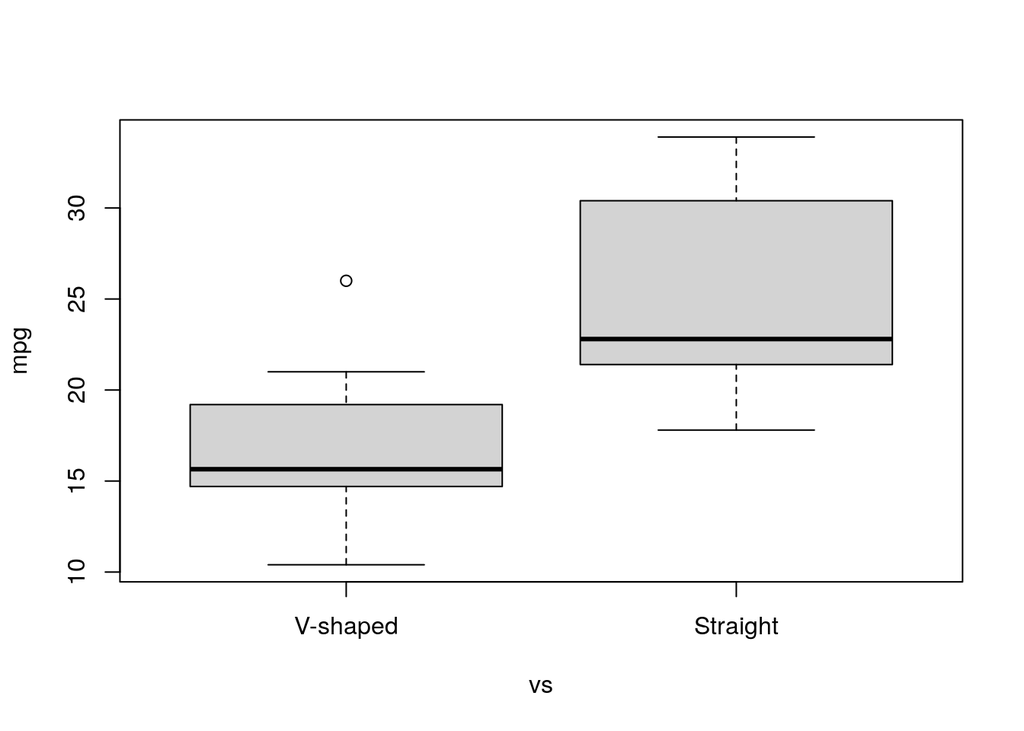

```r
boxplot(mpg ~ vs, data = mtcars, names  = c("V-shaped", "Straight"))
```

### Using ggplot2 package

Again for further and more specific adjustment we could use `ggplot2` instead of base **R**.

```r
library(ggplot2)
```

As with nearly every plot done with `ggplot` we start with making `ggplot` familiar with the data we are using and which parts we want to visualize. As before we want to use the data set `mtcars` and display the fuel consumption `mpg`. Since we want to display the box plot vertically we assign the variable `mpg` to the y-axis.

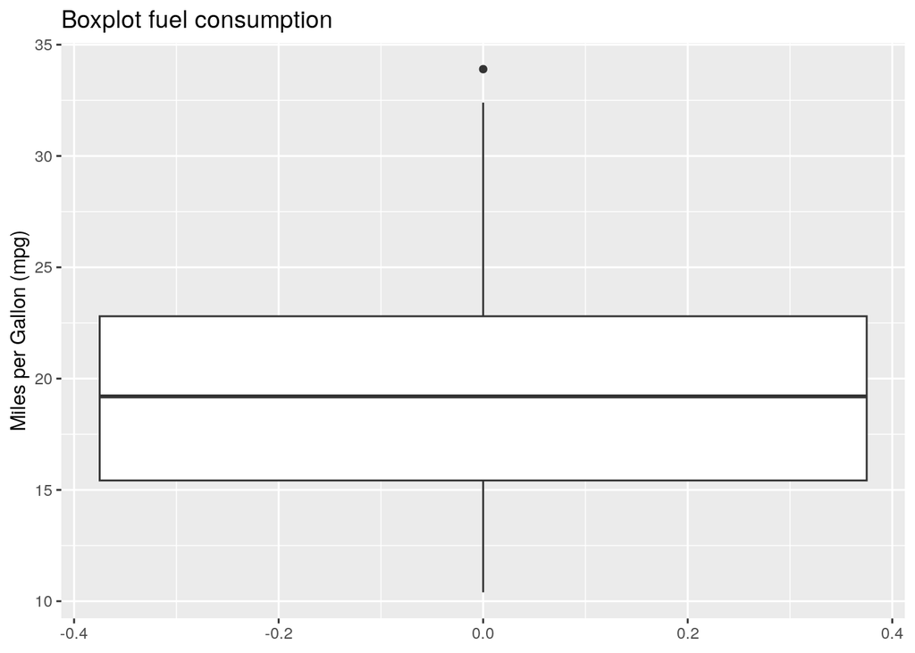

```r
ggplot(mtcars, aes(y = mpg)) +
  geom_boxplot() +
  labs(title = "Boxplot fuel consumption",
       y = "Miles per Gallon (mpg)")
```

If we want to plot the data grouped in the different numbers of cylinders `cyl` we have to make sure that the variable we use to group the data is a factor. We can achieve this by using `as.factor()`.

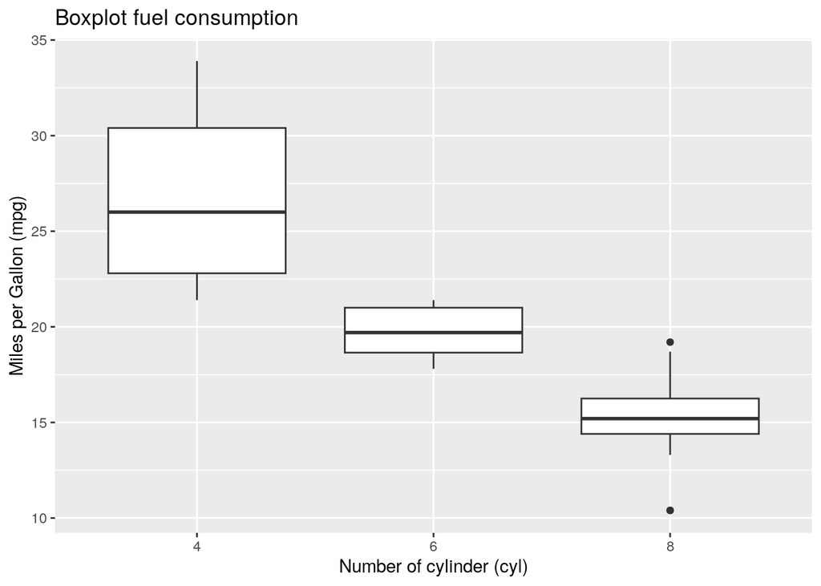

```r
ggplot(mtcars, aes(x = as.factor(cyl), y = mpg)) +
  geom_boxplot() +
  labs(title = "Boxplot fuel consumption",
       x = "Number of cylinder (cyl)",
       y = "Miles per Gallon (mpg)")
```

## Line plot

For continuous data depending on time we often use a line plot, since the the time points often are not equally distributed and a linear interpolation between data points is a reasonable guess. For demonstration we will use the data set `crab_tag` from the `learningr` package.

```r
# Extracting data from package
#data(crab_tag, package = "learningr")
load(file = "data/crab_tag.rda")
crab_tag_daylog = crab_tag$daylog
str(crab_tag_daylog)
```

```
## 'data.frame':    405 obs. of  7 variables:
##  $ Mission.Day: int  0 1 2 3 4 5 6 7 8 9 ...
##  $ Date       : Date, format: "2008-08-08" "2008-08-09" ...
##  $ Max.Temp   : num  27.7 25.2 24 26.5 27 ...
##  $ Min.Temp   : num  25.2 23.9 23.5 23.3 23.6 ...
##  $ Max.Depth  : num  0.06 0.06 -0.07 -0.04 -0.1 -0.04 0.06 0.09 0.03 -0.04 ...
##  $ Min.Depth  : num  -0.07 -0.07 -0.1 -0.1 -0.26 -0.13 -0.04 -0.01 -0.04 -0.1 ...
##  $ Batt.Volts : num  3.06 3.09 3.09 3.09 3.09 3.09 3.09 3.09 3.09 3.09 ...
```

### Using base R

We want to visualize `Max.Depth` depending on `Date` via a line plot. To do this in base R we can simply use `plot()` with the first variable as the first argument `x` and the second variable as the second argument `y`. To get a line plot we also have to set `type = "l"`, since `plot()` is capable of many different kinds of plots.

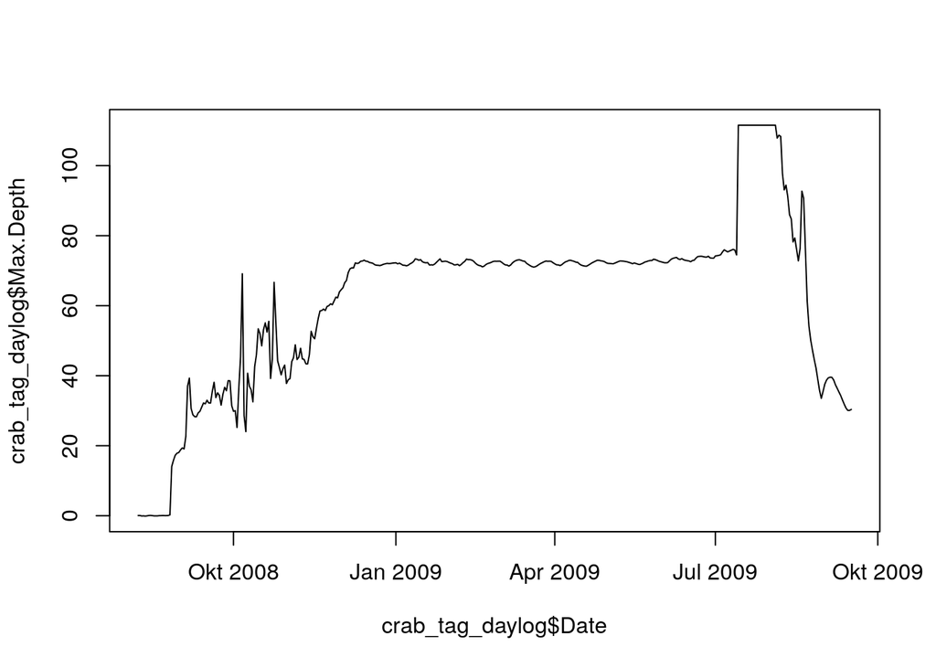

```r
# Drawing line plot
plot(crab_tag_daylog$Date, crab_tag_daylog$Max.Depth, type = "l")
```

Since the `Max.Depth` describes a depth it would be nice to visualize this accordingly. To adjust the plot, we can simply assign a `-` in front of the data and to determine the scaling of the y-axis, we can use `ylim`.

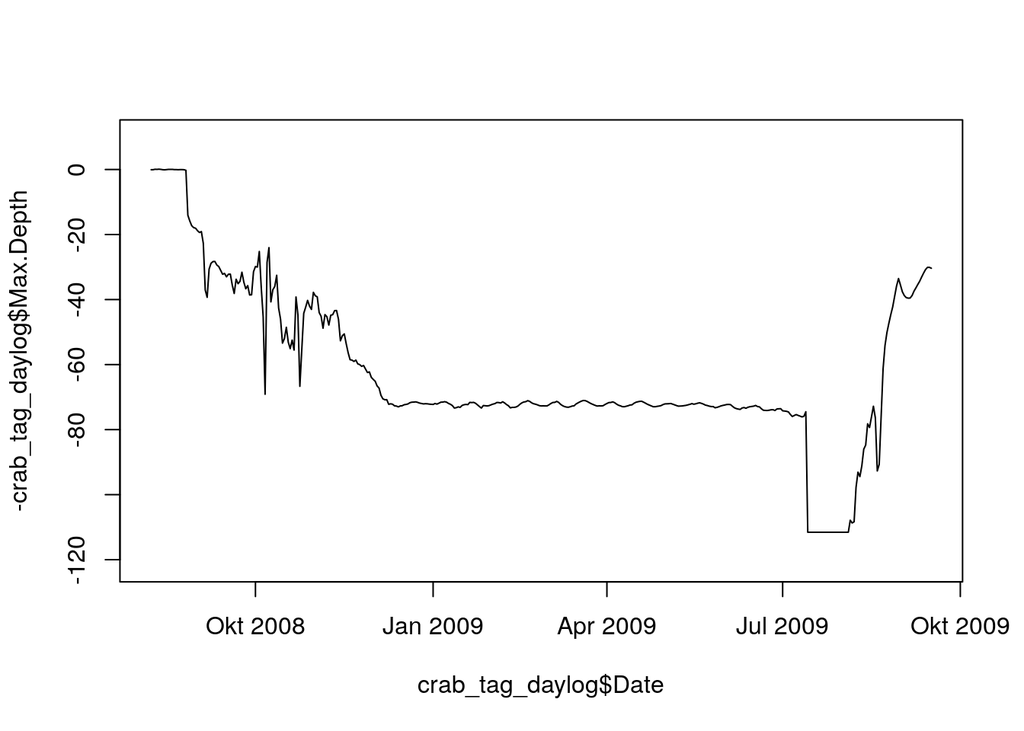

```r
plot(crab_tag_daylog$Date, -crab_tag_daylog$Max.Depth,
     type = "l", ylim = c(-max(crab_tag_daylog$Max.Depth)-10, 10))
```

We can draw multiple lines in the same plot, e.g. if we want to visualize `Max.Depth` and `Min.Depth` simultaneously. We just create the line plot for the first variable and and create the second line in the plot with `line()`. To distinguish the lines we could change their colors by the argument `col`.

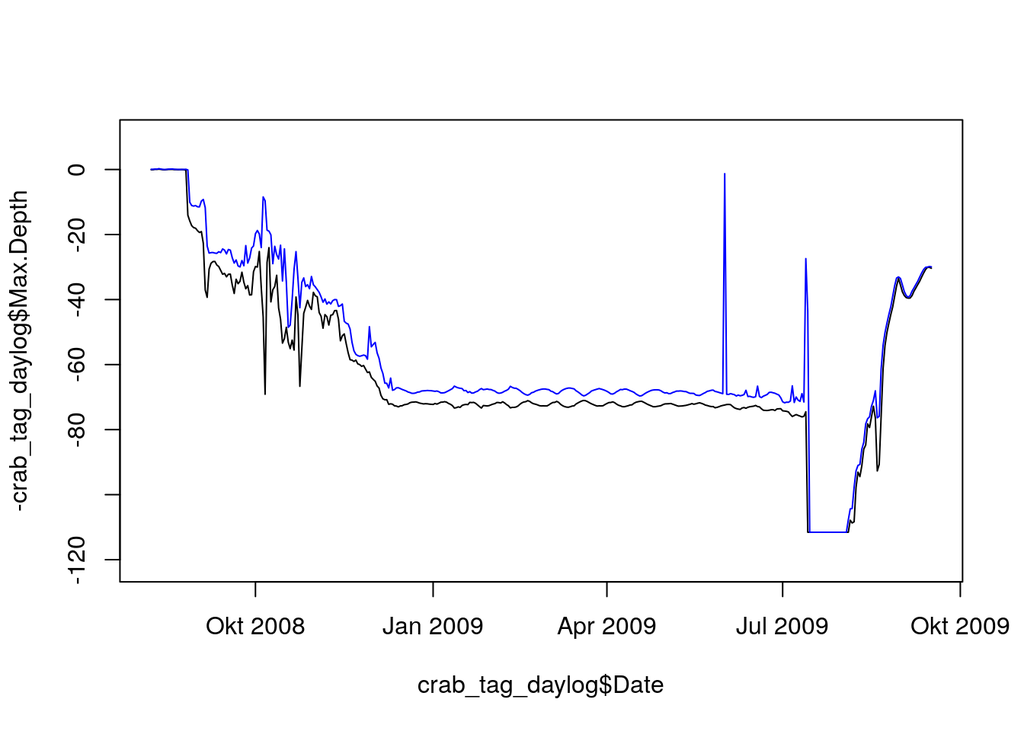

```r
plot(crab_tag_daylog$Date, -crab_tag_daylog$Max.Depth,
     type = "l", ylim = c(-max(crab_tag_daylog$Max.Depth)-10, 10))
# Adding the lines for min depth on the existing plot of max depth

lines(crab_tag_daylog$Date, -crab_tag_daylog$Min.Depth, col = "blue")
```

### Using ggplot2 package

We can do the same with `ggplot2`. If not done yet, load the package with the following line.

```r
library(ggplot2)
```

We first hand `ggplot()` the data we want to use and tell it in `aes()` that we want `Date` along the x-axis. In the second step we add the line via `geom_line()` and the variable it should show. If we want to add another line depicting another variable we simply can add the same command with a different variable. As before we can give different colors to the lines with the argument `colour`.

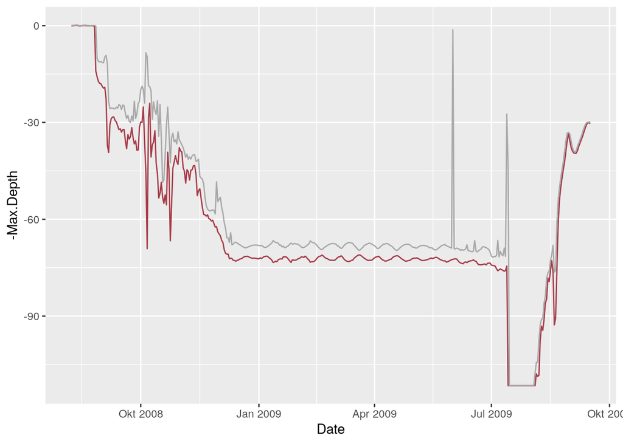

```r
ggplot(crab_tag_daylog, aes(x = Date)) +
geom_line(aes(y = -Max.Depth), colour = "#a83b48") + # google "colour picker" to get the codes
geom_line(aes(y = -Min.Depth), colour = "darkgrey")
```

## Scatter plot

If we want to visualize the relationship of two continuous variables a practicable thing to do is to use a scatter plot. Each variable is assigned the role of a dimension and the resulting data points are then depicted in the resulting two-dimensional space (of course we could do the same with more than two variables, but using more then three becomes harder to visualize properly).

To demonstrate this plot and its creation we want to come back to the data set `obama_vs_mccain` from the begining of the lecture.

```r
load(file ="data/obama_vs_mccain.rda")
```

### Using base R

If we are interested in the correlation of `Income` and `Turnout`, so to speak the question if the income influences the turnout of the poll, we can use a scatter plot to get a visual impression, whether this is plausible or not.

In base R we can simply use `plot()` to create a scatter plot. Since it has no build in mechanism to deal with missing values, we first have to clean our data of these. Afterwards we can hand over the data we want to use for the x-axis `x` and y.axis `y` respectively.

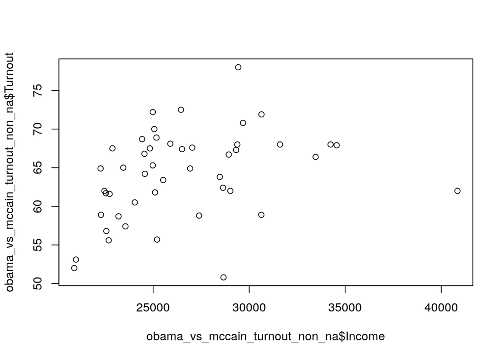

```r
# Deleting NA
obama_vs_mccain_turnout_non_na = obama_vs_mccain[!is.na(obama_vs_mccain$Turnout), ]
# plotting scatter plot
plot(obama_vs_mccain_turnout_non_na$Income, obama_vs_mccain_turnout_non_na$Turnout)
```

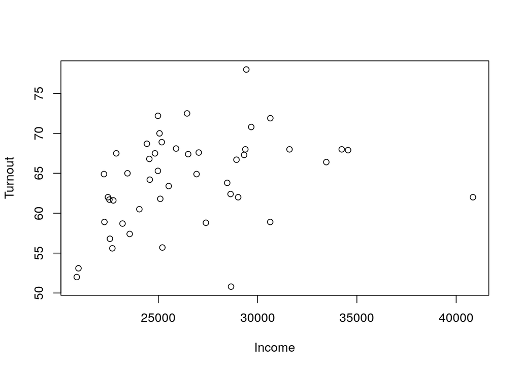

```r
# or using with command
with(obama_vs_mccain_turnout_non_na, plot(Income, Turnout))
```

We can edit the plot by using various parameters as described in the help document `?plot` or `??plot`. For example we can change the color via `col`.

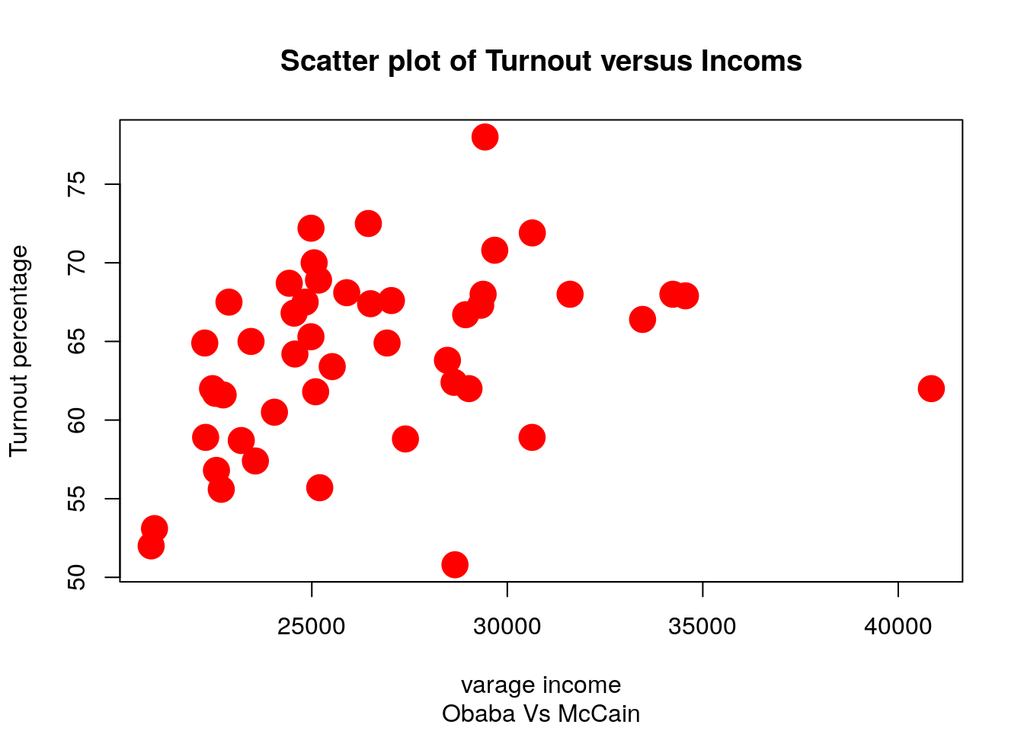

```r
plot(obama_vs_mccain_turnout_non_na$Income,
     obama_vs_mccain_turnout_non_na$Turnout,
     col = "red", pch = 20, cex = 3.5,
     main = "Scatter plot of Turnout versus Incoms",
     sub= "Obaba Vs McCain", xlab = "varage income", ylab = "Turnout percentage")
```

### Using ggplot2 package

Alternatively to base R we can use `ggplot2` to create a scatter plot. If not already done, please load the `ggplot2` package by the following line.

```r
library(ggplot2)
```

To create a scatter plot showing the relation of `Income` and `Turnout` we have to first hand the data set of `ggplot()` and give details about the variables we want to show in `aes()`. Followed by that we use `geom_point()` to create the points of the scatter plot. We can change details of the plot by arguments of the function, e.g. the size of the dots by `size`.

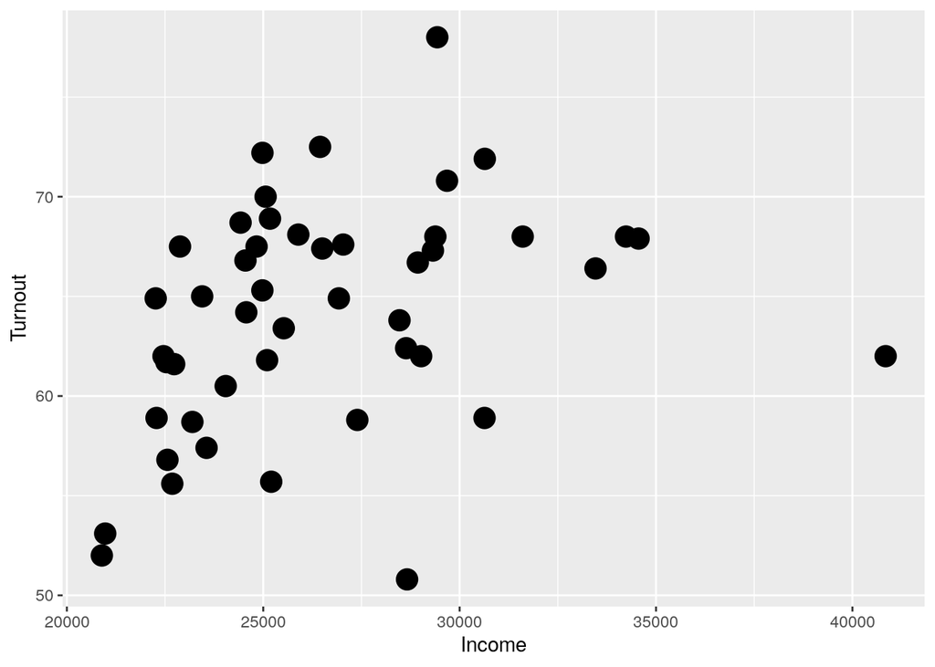

```r
ggplot(obama_vs_mccain_turnout_non_na, aes(x = Income, y = Turnout)) +
geom_point(size = 5)
```

We can use coloring to easily depict a third variable in our two dimensional plot, e.g. to examine the influence of `Region` on the other variables.

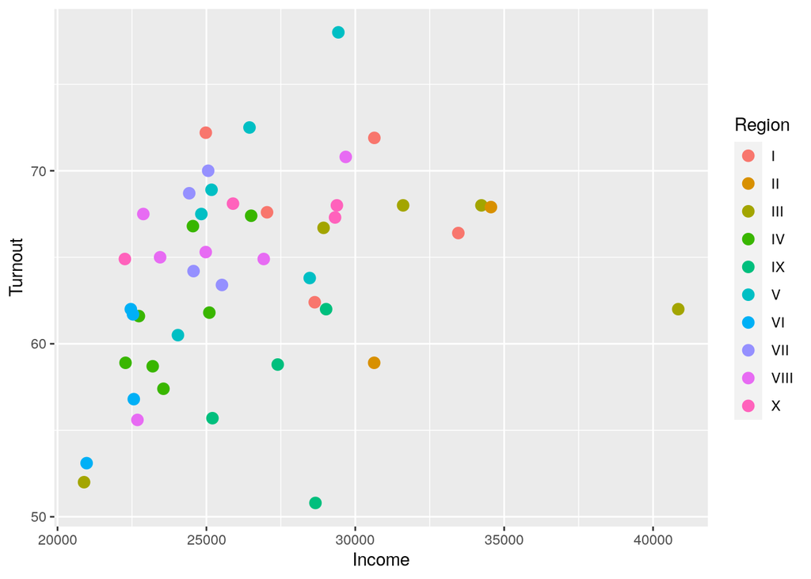

```r
ggplot(obama_vs_mccain_turnout_non_na, aes(x = Income, y = Turnout, color = Region)) +
geom_point(size = 3)
```

To draw individual plots for category in `Region`, we add a *facet* using `facet_wrap()`.

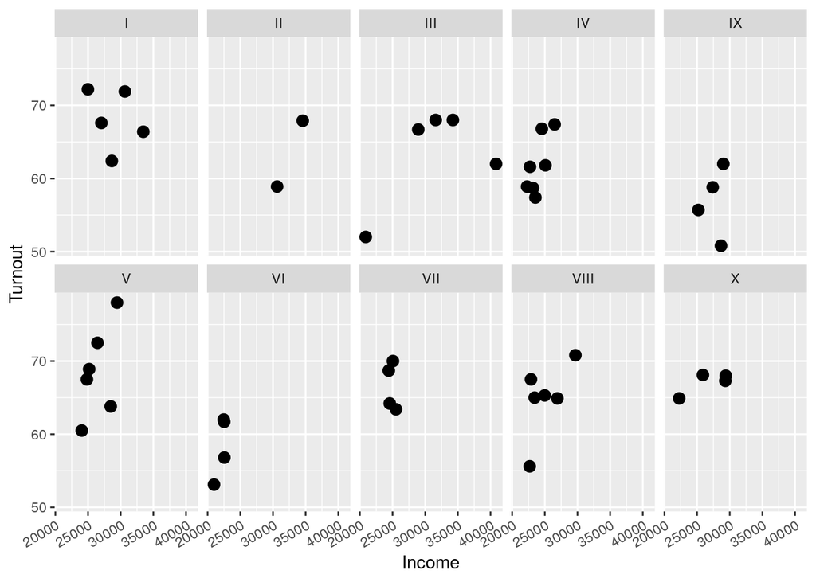

```r
ggplot(obama_vs_mccain_turnout_non_na, aes(x = Income, y = Turnout)) +
  geom_point(size = 3) +
  facet_wrap(~ Region, ncol = 5) +
  theme(axis.text.x = element_text(angle = 30, hjust = 1))   # to rotate x axis
```

## Additional visualizations using ggplot2 package

- [ggplot2 references for further reading](https://r4ds.hadley.nz/data-visualize)
- [ggplot2 references manual](https://cloud.r-project.org/web/packages/ggplot2/ggplot2.pdf)

# Getting help

- [Posit Community, formally known as RStudio community](https://community.rstudio.com/)
- [Stack Overflow link for ggplot](https://stackoverflow.com/questions/tagged/ggplot2?sort=frequent&pageSize=50)
- [ggplot2 GitHub](https://github.com/tidyverse/ggplot2)
- [ggplot2 references for further reading](https://r4ds.hadley.nz/data-visualize)